# Question

Un estudiante tiene un vaso de forma cilíndrica. El vaso tiene una base circular de radio 49 cm y una altura de 64 cm, como se muestra en la figura.

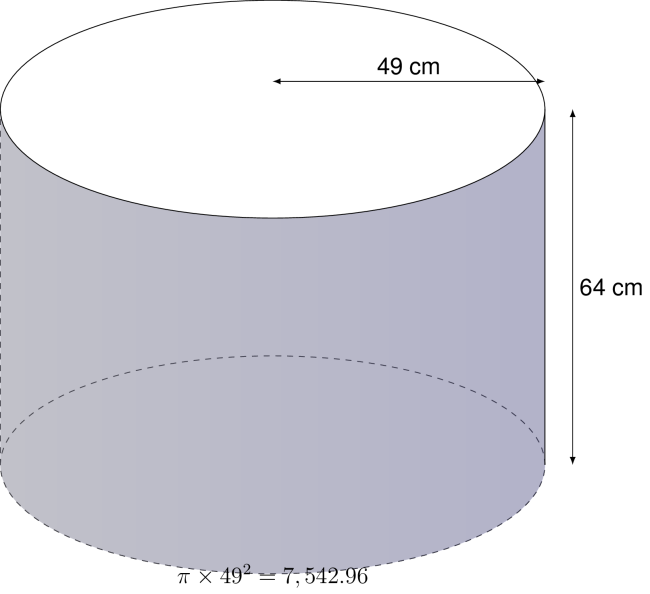

A partir de la información anterior, el estudiante plantea la siguiente operación:

$$\pi \times 49^2 = 7,542.96$$

¿A qué corresponde el resultado de la anterior operación?

## Answerlist

- Al perímetro de la tapa del vaso
- Al área de la tapa del vaso
- Al área lateral del vaso
- Al volumen del vaso

# Solution

Para resolver este problema, debemos identificar qué cálculo se está realizando con la fórmula $\pi \times 49^2 = 7,542.96$.

Analizando la fórmula:

- $\pi \times r^2$ corresponde al área de un círculo con radio $r$

Por lo tanto, la fórmula $A = \pi \times r^2$ es la fórmula del área de un círculo.

Sustituyendo los valores:

- Radio de la base: $r = 49 \text{ cm}$

Calculamos:

$A = \pi \times 49^2 = 7,542.96 \text{ cm}^2$

El resultado corresponde al área de la tapa del vaso cilíndrico, que es la superficie circular que forma la parte superior del vaso.

## Answerlist

- Falso
- Verdadero
- Falso
- Falso

# Meta-information

exname: Area_Tapa_Cilindro extype: schoice exsolution: 0100 exshuffle: TRUE